# Analysis of new data

Matt Jaquiery

27/05/2020

[Script run 2020-09-21 14:06:45]

# Introduction

How we judge our responsibility and the responsibility of others for actions’ outcomes has important consequences in our society. It is tightly related to whether we get rewarded or blamed for the actions we make, which is crucial for the maintenance of a cooperative and fair society. Even in our everyday lives, correctly or wrongfully attributing responsibility to ourselves and others for seemingly non crucial actions, can have emotional and long-term consequences.

How people attribute responsibility to themselves in a group is subjective: They tend to attribute higher responsibility for positive as compared to negative outcomes. This is known as the self-serving bias, where people claim more credit for positive events, while they duck responsibility for negative events (Caine & Schlenker, 1979; Forsyth & Schlenker, 1977; Leary & Forsyth, 1987; Miller & Schlenker, 1985). This bias however does not seem to be purely selfish: it also appears when people judge their group or another person’s responsibility (Palmeira et al., 2015; Taylor & Doria, 1981). For example, in the context of advising, people exhibit an ‘other-serving’ bias as they tend to credit more than blame an advisor (Palmeira et al., 2015).

In individual contexts, the rewards naturally seem to belong to the person producing a positive or negative outcome. In a group decision however, the outcome may be shared or given to one group member. It has been established that responsibility underlies ownership: control and intent of an action, which are directly associated with responsibility attributions, also predict whether a person is perceived as the owner of an object (Palamar et al., 2012). If attributions of responsibility predict ownership, is the opposite true? Here we would like to address 1) whether *Outcome ownership* changes attributions of responsibility and 2) whether *Outcome ownership* is necessary for the self-serving and/or other-serving bias to appear.  
We investigate this question in a group decision-making context, where only one member can receive the outcome in each round.

Participants will perform an online task where they make collective decisions through majority votes, then one member of the group can receive either a *Reward* or *No reward*. Finally they will rate the responsibility of the group members for the outcome. This paradigm will allow us to address both questions stated above:

1. by investigating whether responsibility attribution increases for the *Outcome owner*, although the control over the outcome is exactly similar.
2. By checking whether the self and other-serving bias of higher responsibility ratings for positive outcomes depend on *Outcome ownership*.

In other words, we will answer the question: do people exhibit the same self-serving bias when judging the responsibility for an outcome that is attributed to another member of their group? Do they also still exhibit an ‘other-serving’ bias when judging the responsibility of another group member who did not receive the outcome? We will also investigate (1b) whether self- and other-serving biases are of similar strength.[^1]

- Whether the rated player is the *Outcome recipient*:
  - *Outcome owner* versus *Not outcome owner*
- The *Outcome valence*:
  - *Reward* versus *No reward*
- The *Vote status* of the participant in the group decision process:
  - *Participant in majority* versus *Participant in minority*
- Whether the *Responsibility judgement* is made about:
  - *Own responsibility* versus *Another’s responsibility*
  - In this experiment, all *Responsibility judgements* are made about *Another’s responsibility*

# Method

## Statistical analysis

The primary analysis technique is ANOVA (Bayesian and frequentist). Bayesian ANOVA results are obtained by taking the likelihood of a model with the effect of interest plus all simpler effects compared to an alternative containing only the simpler effects. For main effects, this is the model for the effect alone compared to the intercept-only model; for one-way interactions this is the main effects plus interaction-of-interest model compared to the main effects only model.

## Materials

Experiments were custom-written in HTML/CSS/JavaScript using the [jsPsych framework](https://www.jspsych.org/) and undertaken by participants over the internet using their own devices. The experiment code was written by Marwa El Zein.

## Procedure

The entry point to the study is through recruitment on the Prolific (https://prolific.ac/) participant recruitment platform. Participants accepting the study are forwarded to the experiment website, where they provide informed consent for participation before entering the main experiment page. The experiment begins with detailed instruction pages which describe the structure of each round in the game, with screenshots of each stage, followed by a short training trial sequence. Once they have read the instructions and familiarised themselves with the game, participants begin the main experiment, which consists of 3 blocks of 20 trials. The 20 trials are a randomised sequence of balanced repetitions of each of the 8 unique trial types (as defined by whether the outcome is a reward/no reward; whether the participant is in the majority/minority; and whether the participant receives the outcome). The a reward/no reward trials and the trials with the participant in the majority/minority occurred equally frequently, while the participant received the outcome on 40% of all trials (because we wanted to maximise this variation but felt that 50% of trials might be noticeably unrealistic with four other players in the game).

Each trial begins with a display of the five players. This is followed by a screen in which the participant selects one of two gamble images. Gamble images are selected from a collection of hand-drawn images of gambling devices and paraphernalia, and are counterbalanced such that each pair of images is shown the same number of times. Which gamble is selected has no influence on the outcome of the trial, which is predetermined. Once the participant selects a gamble the other option vanishes.

If the participant has not selected a gamble by the end of the choice window, the rest of the trial is cancelled and the participant is shown a warning message which states that they have failed to make a choice in time. If the participant did select a gamble, the next screen indicates which gamble has been selected through the majority vote of all five players. Next, the gamble is allocated to one of the players and its outcome is shown (a coin for a rewarded trial or a coin with a cross through it for an unrewarded trial).

Finally, the participant is asked to rate their own responsibility for the outcome using a slider. The responsibility rating phase lasts until the responsibility ratings has been submitted.

Once all 60 experimental trials have been completed, participants are debriefed, thanked, and returned to Prolific. Payment follows once all participants have completed the study and bonuses have been calculated.

## Open science

### Preregistration

Experiment 2 was [preregistered on the Open Science Framework platform (OSF)](https://osf.io/mhsfq). The analysis plan deviated from the preregistration in that participants are removed for using the same gamble choice response key on consecutive trials only if they used the same key for all trials in a block (after removing trials with no response).

### Open materials

Materials for the studies can be found on the [GitHub repository](https://github.com/mjaquiery/responsibility-by-reward/tree/841d12c51d00102e13c61829bdbbbdb311e8e715/ATTRRESP/) as it stood on 26th May 2020.

### Open data

We are happy to share the experimental data for these pilot studies, but may not upload them to a repository unless requested. Data for the main experiments will available online.

[output not shown]

### Exclusions

(#tab:exclusions)

| Reason | N excluded |
| --- | --- |
| double_entry | 0.00 |
| missed_trials | 11.00 |
| trial_count | 5.00 |
| consec_resp | 3.00 |
| total_unique_exclusions | 16.00 |

### Demographics

(#tab:participant demographics)

| gender | n |
| --- | --- |
| F | 21 |
| M | 35 |

Participants self-reported a mean age of 22.7 (SD = 4.5) years and their genders as M (35), F (21), or otherwise (0).

Data were collected on the following days:

(#tab:experiment dates)

| Date | Participants |
| --- | --- |
| 26/05/2020 | 56 |

### Response times

Participants make two responses on a trial, choosing a gamble and indicating their feeling of responsibility. The distributions of the timings of these events for each participant are shown below for the first 15 seconds of the trials. The 35 responses which took longer than 15 seconds have been removed from this plot (the number for each participant is indicated in grey text), but remain in the responsibility rating data analysed in the main analysis.

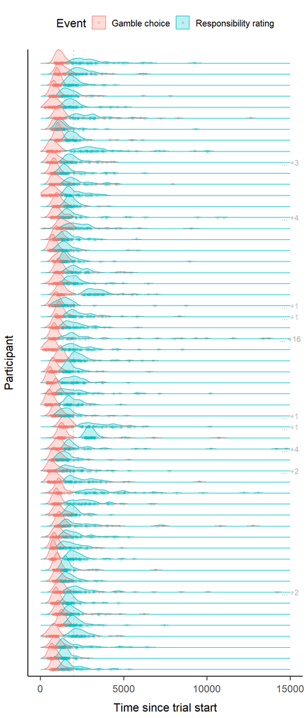

### Feeling of responsibility scale usage

This plot shows each participant’s use of the responsibility rating scale, i.e. their answers to the question of how responsible they felt on each trial.

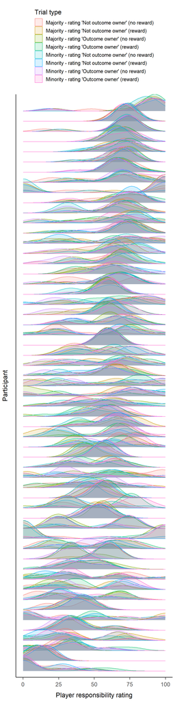

## Inferential statistics

### 1) Are players considered more responsible if they are the *Outcome owner*?

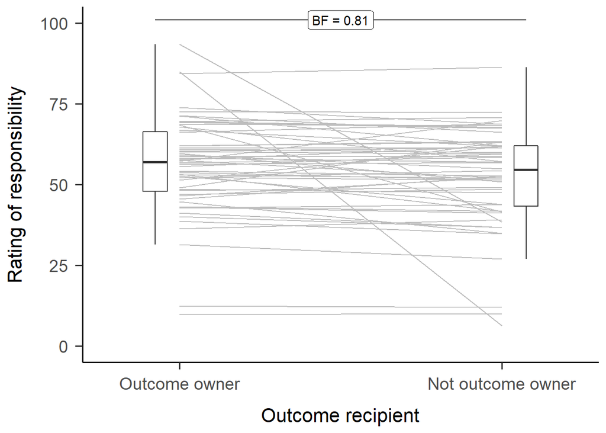

The figure shows participant mean responsibility ratings collapsed across other trial factors (lines) and their distributions (box plots). Participants rate players’ responsibility as higher when that player receives the outcome.

### 2) Does the other-serving bias, i.e, higher responsibility for positive *Outcome valence*, change if the rated player is *Not outcome owner*?

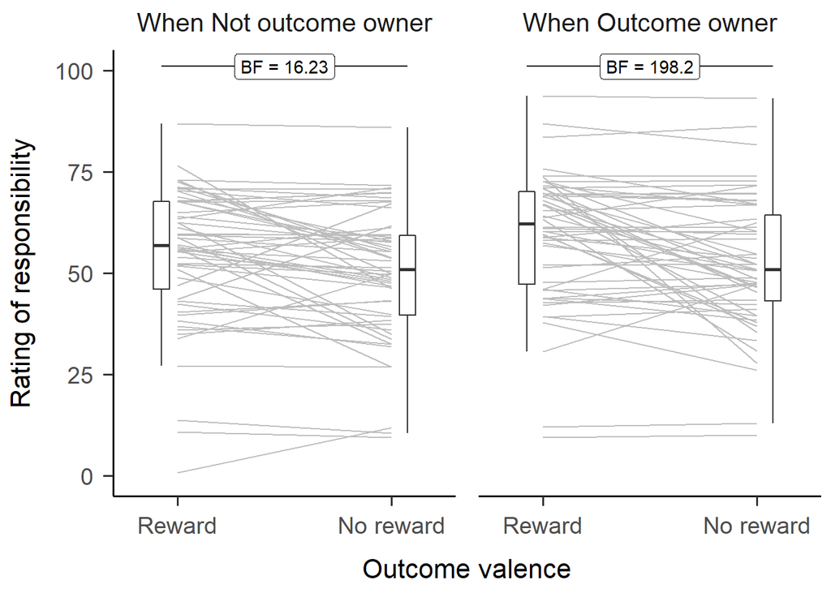

We explored this statistically with a 2x2x2 ANOVA but we did not see the expected interaction between the effects of whether the participant receives the outcome (‘getsout’) and whether the outcome was good (‘outcome’). The Bayesian ANOVa suggested this interaction was sensitively null, in other words it offered evidence against the existence of this interaction.

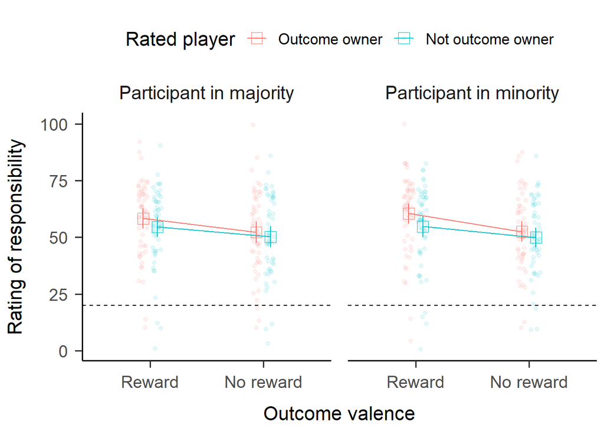

The figure shows participant mean self-responsibility ratings collapsed in each trial type (coloured dots). Squares indicate the mean for a trial type across all participant means, with the error bars giving 95% confidence intervals.

(#tab:ANOVA results)

|  | Effect | DFn | DFd | F | p | p<.05 | ges |
| --- | --- | --- | --- | --- | --- | --- | --- |
| ANOVA |  |  |  |  |  |  |  |
| 2 | outcome | 1.00 | 55.00 | 19.18 | 0.00 | * | 0.03 |
| 3 | getsout | 1.00 | 55.00 | 3.59 | 0.06 |  | 0.01 |
| 4 | status | 1.00 | 55.00 | 0.61 | 0.44 |  | 0.00 |
| 5 | outcome:getsout | 1.00 | 55.00 | 2.32 | 0.13 |  | 0.00 |
| 6 | outcome:status | 1.00 | 55.00 | 0.91 | 0.34 |  | 0.00 |
| 7 | getsout:status | 1.00 | 55.00 | 1.00 | 0.32 |  | 0.00 |
| 8 | outcome:getsout:status | 1.00 | 55.00 | 0.43 | 0.51 |  | 0.00 |

(#tab:Bayesian ANOVA results)

| M1 | M2 | BF.M1.M2 |  |
| --- | --- | --- | --- |
| status + outcome + getsout + subject_id | status + getsout + subject_id | 4,171,346,219,697.50 | + |
| status + outcome + getsout + subject_id | status + outcome + subject_id | 24,252.39 | + |
| status + outcome + getsout + subject_id | outcome + getsout + subject_id | 0.05 | - |
| status + outcome + getsout + outcome:getsout + subject_id | status + outcome + getsout + subject_id | 0.20 | - |
| status + outcome + status:outcome + getsout + subject_id | status + outcome + getsout + subject_id | 0.07 | - |
| status + outcome + getsout + status:getsout + subject_id | status + outcome + getsout + subject_id | 0.08 | - |
| status + outcome + status:outcome + getsout + status:getsout + outcome:getsout + status:outcome:getsout + subject_id | status + outcome + status:outcome + getsout + status:getsout + outcome:getsout + subject_id | 0.09 | - |

The Bayesian and frequentist ANOVAs agree on the presence of an effect of *Outcome valence* where responsibility ratings are higher for *Reward* than *No reward* trials. The Bayesian ANOVA showed an effect of *Outcome recipient* whereby the *Outcome owner* received higher responsibility ratings, where no significant effect appeared in the frequentist ANOVA. The Bayesian ANOVA showed all the other effects as sensitive null results, which were consistent with the non-significant frequentist tests. Crucially, these null results include the key interaction between *Outcome valence* and *Outcome owner*. This indicates that the other-serving bias is equivalent whether or not the rated player has received the outcome.

### Participant included data

We may have enough data to explore this with an additional factor: whether the participant was the receiving player. We don’t place much weight on these analyses because the experiment was not constructed to provide a balanced design: there are for example no trials on which the participant rated their own responsibility but the outcome was given to another player.

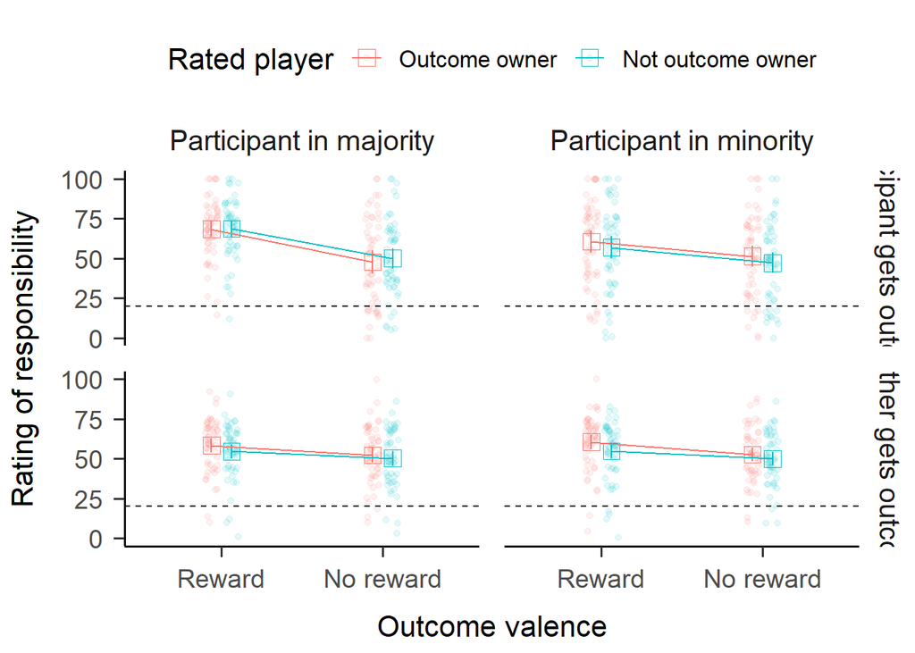

(#tab:unnamed-chunk-5)

|  | Effect | DFn | DFd | F | p | p<.05 | ges |
| --- | --- | --- | --- | --- | --- | --- | --- |
| ANOVA |  |  |  |  |  |  |  |
| 2 | outcome | 1.00 | 55.00 | 39.90 | 0.00 | * | 0.06 |
| 3 | getsout | 1.00 | 55.00 | 5.17 | 0.03 | * | 0.00 |
| 4 | status | 1.00 | 55.00 | 6.27 | 0.02 | * | 0.00 |
| 5 | pgetsout | 1.00 | 55.00 | 1.94 | 0.17 |  | 0.00 |
| 6 | outcome:getsout | 1.00 | 55.00 | 1.04 | 0.31 |  | 0.00 |
| 7 | outcome:status | 1.00 | 55.00 | 4.93 | 0.03 | * | 0.00 |
| 8 | getsout:status | 1.00 | 55.00 | 3.56 | 0.06 |  | 0.00 |
| 9 | outcome:pgetsout | 1.00 | 55.00 | 10.29 | 0.00 | * | 0.01 |
| 10 | getsout:pgetsout | 1.00 | 55.00 | 0.71 | 0.40 |  | 0.00 |
| 11 | status:pgetsout | 1.00 | 55.00 | 7.22 | 0.01 | * | 0.00 |
| 12 | outcome:getsout:status | 1.00 | 55.00 | 0.06 | 0.81 |  | 0.00 |
| 13 | outcome:getsout:pgetsout | 1.00 | 55.00 | 0.27 | 0.61 |  | 0.00 |
| 14 | outcome:status:pgetsout | 1.00 | 55.00 | 5.95 | 0.02 | * | 0.00 |
| 15 | getsout:status:pgetsout | 1.00 | 55.00 | 1.73 | 0.19 |  | 0.00 |
| 16 | outcome:getsout:status:pgetsout | 1.00 | 55.00 | 0.65 | 0.42 |  | 0.00 |

(#tab:unnamed-chunk-6)

| M1 | M2 | BF.M1.M2 |  |
| --- | --- | --- | --- |
| status + outcome + getsout + pgetsout + subject_id | status + getsout + pgetsout + subject_id | 54,176,648,337,944,636,676,424,646.00 | + |
| status + outcome + getsout + pgetsout + subject_id | status + outcome + pgetsout + subject_id | 5,829.08 | + |
| status + outcome + getsout + pgetsout + subject_id | outcome + getsout + pgetsout + subject_id | 0.05 | - |
| status + outcome + getsout + pgetsout + subject_id | status + outcome + getsout + subject_id | 2.20 |  |
| status + outcome + getsout + outcome:getsout + subject_id | status + outcome + getsout + pgetsout + subject_id | 0.07 | - |
| status + outcome + status:outcome + getsout + subject_id | status + outcome + getsout + pgetsout + subject_id | 0.03 | - |
| status + getsout + status:getsout + pgetsout + subject_id | status + outcome + getsout + pgetsout + subject_id | 0.00 | - |
| status + outcome + pgetsout + outcome:pgetsout + subject_id | status + outcome + getsout + pgetsout + subject_id | 6.93 | + |
| status + getsout + pgetsout + getsout:pgetsout + subject_id | status + outcome + getsout + pgetsout + subject_id | 0.00 | - |
| status + outcome + pgetsout + status:pgetsout + subject_id | status + outcome + getsout + pgetsout + subject_id | 0.00 | - |
| status + outcome + status:outcome + getsout + status:getsout + outcome:getsout + status:outcome:getsout + pgetsout + status:pgetsout + outcome:pgetsout + getsout:pgetsout + subject_id | status + outcome + status:outcome + getsout + status:getsout + outcome:getsout + pgetsout + status:pgetsout + outcome:pgetsout + getsout:pgetsout + subject_id | 0.12 | - |
| status + outcome + status:outcome + getsout + status:getsout + outcome:getsout + pgetsout + status:pgetsout + outcome:pgetsout + getsout:pgetsout + outcome:getsout:pgetsout + subject_id | status + outcome + status:outcome + getsout + status:getsout + outcome:getsout + pgetsout + status:pgetsout + outcome:pgetsout + getsout:pgetsout + subject_id | 0.09 | - |
| status + outcome + status:outcome + getsout + status:getsout + outcome:getsout + pgetsout + status:pgetsout + outcome:pgetsout + status:outcome:pgetsout + getsout:pgetsout + subject_id | status + outcome + status:outcome + getsout + status:getsout + outcome:getsout + pgetsout + status:pgetsout + outcome:pgetsout + getsout:pgetsout + subject_id | 43.66 | + |
| status + outcome + status:outcome + getsout + status:getsout + outcome:getsout + pgetsout + status:pgetsout + outcome:pgetsout + getsout:pgetsout + status:getsout:pgetsout + subject_id | status + outcome + status:outcome + getsout + status:getsout + outcome:getsout + pgetsout + status:pgetsout + outcome:pgetsout + getsout:pgetsout + subject_id | 0.17 | - |
| status + outcome + status:outcome + getsout + status:getsout + outcome:getsout + status:outcome:getsout + pgetsout + status:pgetsout + outcome:pgetsout + status:outcome:pgetsout + getsout:pgetsout + s… | status + outcome + status:outcome + getsout + status:getsout + outcome:getsout + status:outcome:getsout + pgetsout + status:pgetsout + outcome:pgetsout + status:outcome:pgetsout + getsout:pgetsout + s… | 0.08 | - |

Many of the effects of this analysis are significant on the frequentist analysis but unclear or null on the Bayesian analysis. This indicates that the data are not stable across analytical tools which should identify the same patterns, increasing the need for caution in interpretation. The effects which are agreed upon by both analyses are the main effects of *Outcome valence* and *Outcome owner*, the interaction between *Outcome valence* and whether the *Participant gets the outcome*, and the three-way interaction between the *Outcome valence*, the *Vote status*, and whether the *Participant gets the outcome*. All the other significant effects were ruled as null results by the Bayesian ANOVA, specifically the main effect of *Vote status*, the interaction of *Outcome valence* and *Vote status*, and the interaction of *Vote status* and whether the *Participant gets the outcome*. The remaining effects were sensitively null in the Bayesian analysis, except for the main effect of whether the *Participant gets the outcome*, which was inconclusive.

Notably, the interactions of interest were both sensitively null: the interaction between *Outcome valence* and *Outcome owner*, and the interaction of these two with whether the *Participant gets the outcome*.

# Interpretation

The effect seen in Pilot 1, in which participants’ feelings of responsibility were increased where the participant received the outcome of the chosen gamble (whether or not the outcome was a reward), were not found when participants rated other players’ responsibility rather than their own. Similarly, the finding that this increase was greater where the outcome was a reward rather than no reward was also not found where participants rated other players’ responsibility.

We aim to condense both experiments into a single, simpler design. This design should allow balancing between participants receiving the outcomes and not receiving the outcomes, and allow for comparable ratings of one’s own and others’ responsibility for decisions.

# References

Bruce T. Caine and Barry R. Schlenker. Role Position and Group Performance as Determinants of Egotistical Perceptions in Cooperative Groups. The Journal of Psychology, 101(2):149–156, March 1979. ISSN0022-3980. doi: 10.1080/00223980.1979.9915066. URL https://doi.org/10.1080/00223980.1979.9915066.

John M. Darley and Bibb Latane. Bystander intervention in emergencies: Diffusion of responsibility. Journal of Personality and Social Psychology, 8(4, Pt.1):377–383,1968. ISSN 1939-1315(Electronic), 0022-3514(Print). doi: 10.1037/h0025589.

Donelson R. Forsyth, Linda E. Zyzniewski, and Cheryl A. Giammanco. Responsibility Diffusion in Cooperative Collectives. Personality and Social PsychologyBulletin, 28(1):54–65, January 2002. ISSN 0146-1672. doi:10.1177/0146167202281005.URL https://doi.org/10.1177/0146167202281005.

Donelson R. Forsyth and Barry R. Schlenker. Attributing the causes of group performance: Effects of performance quality, task importance, and future testing. Journal of Personality, 45(2):220–236, 1977. ISSN 1467-6494(Electronic), 0022-3506(Print). doi:10.1111/j.1467-6494.1977.tb00148.x.

Mark R. Leary and Donelson R. Forsyth. Attributions of responsibility for collective endeavors. In Group processes, Review of personality and social psychology, Vol. 8., pages167–188. Sage Publications, Inc, Thousand Oaks, CA, US,1987. ISBN 978-0-8039-3071-1 978-0-8039-3072-8.

Rowland S. Miller and Barry R. Schlenker. Egotism in Group Members: Public and Private Attributions of Responsibility for Group Performance. Social Psychology Quarterly, 48(1):85–89,1985. ISSN 0190-2725.doi:10.2307/3033785. URL https://www.jstor.org/stable/3033785.

Mauricio Palmeira, Gerri Spassova, and Hean TatKeh. Other-serving bias in advice-taking: When advisors receive more credit than blame. Organizational Behavior and Human Decision Processes, 130:13–25, September 2015. ISSN 0749-5978.doi:10.1016/j.obhdp.2015.06.001. URL http://www.sciencedirect.com/science/article/pii/S0749597815000692.

Max Rollwage, Franziska Pannach, Caedyn Stinson, Ulf Toelch, Igor Kagan, and Arezoo Pooresmaeili. Judgments of effort exerted by others are influenced by received rewards. Scientific Reports, 10(1):1–14, February 2020. ISSN 2045-2322. doi: 10.1038/s41598-020-58686-0. URLhttps://www.nature.com/articles/s41598-020-58686-0.

Donald M. Taylor and Janet R. Doria. Self-Serving and Group-Serving Bias in Attribution. The Journal of Social Psychology, 113(2):201–211, April 1981. ISSN0022-4545. doi: 10.1080/00224545.1981.9924371. URL https://doi.org/10.1080/00224545.1981.9924371. Publisher: Routledge_eprint: https://doi.org/10.1080/00224545.1981.9924371.

# Credits

## R Packages

(#tab:R packages)

| Package | Citations |
| --- | --- |
| base | R Core Team (2020). R: A language and environment for statistical computing. R Foundation for Statistical Computing, Vienna, Austria. URL https://www.R-project.org/. |
| papaja | Aust, F. & Barth, M. (2020). papaja: Prepare reproducible APA journal articles with R Markdown. R package version 0.1.0.9997, retrieved from https://github.com/crsh/papaja |
| BayesFactor | Richard D. Morey and Jeffrey N. Rouder (2018). BayesFactor: Computation of Bayes Factors for Common Designs. R package version 0.9.12-4.2. https://CRAN.R-project.org/package=BayesFactor |
| Matrix | Douglas Bates and Martin Maechler (2019). Matrix: Sparse and Dense Matrix Classes and Methods. R package version 1.2-18. https://CRAN.R-project.org/package=Matrix |
| coda | Martyn Plummer, Nicky Best, Kate Cowles and Karen Vines (2006). CODA: Convergence Diagnosis and Output Analysis for MCMC, R News, vol 6, 7-11 |
| ez | Michael A. Lawrence (2016). ez: Easy Analysis and Visualization of Factorial Experiments. R package version 4.4-0. https://CRAN.R-project.org/package=ez |
| ggridges | Claus O. Wilke (2020). ggridges: Ridgeline Plots in ‘ggplot2’. R package version 0.5.2. https://CRAN.R-project.org/package=ggridges |
| forcats | Hadley Wickham (2020). forcats: Tools for Working with Categorical Variables (Factors). R package version 0.5.0. https://CRAN.R-project.org/package=forcats |
| stringr | Hadley Wickham (2019). stringr: Simple, Consistent Wrappers for Common String Operations. R package version 1.4.0. https://CRAN.R-project.org/package=stringr |
| dplyr | Hadley Wickham, Romain François, Lionel Henry and Kirill Müller (2020). dplyr: A Grammar of Data Manipulation. R package version 1.0.0. https://CRAN.R-project.org/package=dplyr |
| purrr | Lionel Henry and Hadley Wickham (2020). purrr: Functional Programming Tools. R package version 0.3.4. https://CRAN.R-project.org/package=purrr |
| readr | Hadley Wickham, Jim Hester and Romain Francois (2018). readr: Read Rectangular Text Data. R package version 1.3.1. https://CRAN.R-project.org/package=readr |
| tidyr | Hadley Wickham and Lionel Henry (2020). tidyr: Tidy Messy Data. R package version 1.1.0. https://CRAN.R-project.org/package=tidyr |
| tibble | Kirill Müller and Hadley Wickham (2020). tibble: Simple Data Frames. R package version 3.0.1. https://CRAN.R-project.org/package=tibble |
| ggplot2 | H. Wickham. ggplot2: Elegant Graphics for Data Analysis. Springer-Verlag New York, 2016. |
| tidyverse | Wickham et al., (2019). Welcome to the tidyverse. Journal of Open Source Software, 4(43), 1686, https://doi.org/10.21105/joss.01686 |

## Funding

Marwa El Zein is a Sir Henry Wellcome Postdoctoral Fellow at University College London, funded by The Wellcome Trust.

Matt Jaquiery is funded by a studentship from the [Medical Research Council](https://mrc.ukri.org/) (reference 1943590) and the University of Oxford [Department of Experimental Psychology](https://www.psy.ox.ac.uk/) (reference 17/18_MSD_661552).